# Homework 2: PCA for Image Compression

Chris Franco

## The compression function

```r
pca_compress <- function(X, k) {
  X <- as.matrix(X)
  e <- eigen(crossprod(X), symmetric = TRUE)  # V = X'X = U Lambda U'
  U <- e$vectors
  Z <- X %*% U                                # PC scores
  Xk <- Z[, 1:k, drop = FALSE] %*% t(U[, 1:k, drop = FALSE])
  err <- norm(X - Xk, type = "F")             # Frobenius norm
  list(approx = Xk, error = err)
}
```

```r
x <- data.matrix(read_csv("data/image1.csv"))
dim(x)
```

```
## [1] 1000  100
```

```r
pca_compress(x, 100)$error
```

```
## [1] 6.299198e-12
```

## Setup

These helper functions are used for every image below. `plot_img()` draws a matrix as an upright grayscale image, and `pca_parts()` does the eigendecomposition once so that every rank-$k$ approximation and every error can be computed from the stored pieces.

```r
plot_img <- function(M, main = "", rng = range(M)) {
  M <- pmin(pmax(M, rng[1]), rng[2])
  image(t(M[nrow(M):1, ]), col = gray.colors(256), axes = FALSE, main = main,
        asp = nrow(M) / ncol(M), zlim = rng)
}

pca_parts <- function(X) {
  X <- as.matrix(X)
  e <- eigen(crossprod(X), symmetric = TRUE)
  U <- e$vectors
  s <- sign(colSums(U)); s[s == 0] <- 1   # eigenvector signs are arbitrary
  U <- sweep(U, 2, s, "*")
  Z <- X %*% U
  lambda <- pmax(e$values, 0)
  err <- sqrt(pmax(sum(lambda) - cumsum(lambda), 0))
  list(X = X, U = U, Z = Z, lambda = lambda, error = err)
}

approx_k <- function(P, k) {
  P$Z[, 1:k, drop = FALSE] %*% t(P$U[, 1:k, drop = FALSE])
}
```

## Image 1

```r
P1 <- pca_parts(x)
n1 <- nrow(x); p1 <- ncol(x); rng1 <- range(x)
round(P1$lambda[1:5], 1)
```

```
## [1] 399104.4   1675.7   1650.1   1607.6   1594.5
```

### Original and rank 1–10 approximations

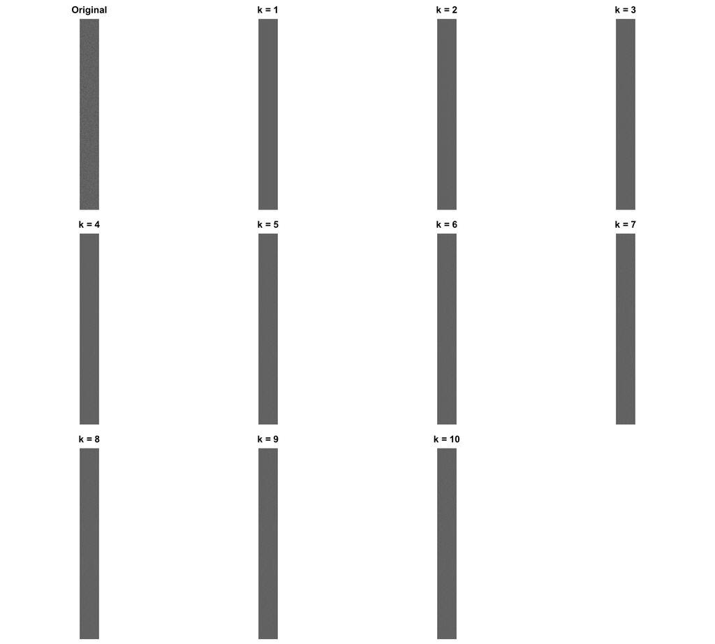

```r
par(mfrow = c(3, 4), mar = c(0.5, 0.5, 2, 0.5))
plot_img(x, "Original", rng = rng1)
for (k in 1:10) plot_img(approx_k(P1, k), paste("k =", k), rng = rng1)
par(mfrow = c(1, 1), mar = c(5, 4, 4, 2) + 0.1)
```

### Approximation error vs. k

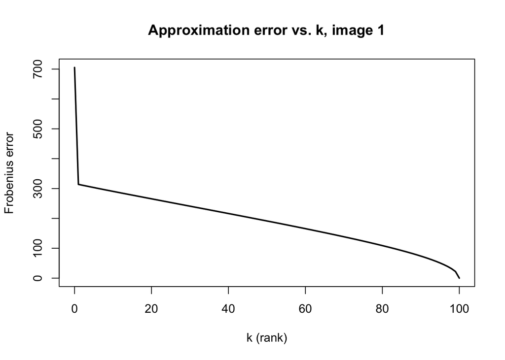

```r
plot(0:p1, c(norm(x, type = "F"), P1$error), type = "l", lwd = 2,
     xlab = "k (rank)", ylab = "Frobenius error",
     main = "Approximation error vs. k, image 1")
```

### First eigenvector and first PC score

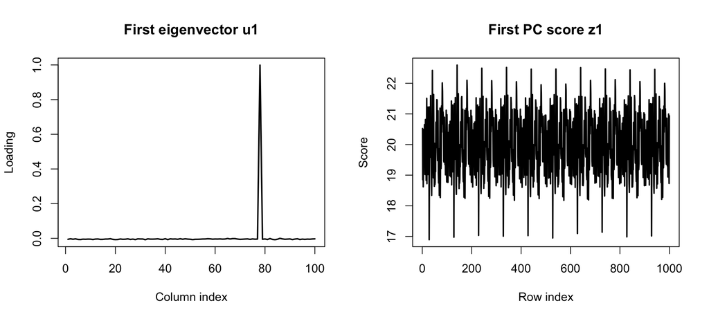

```r
par(mfrow = c(1, 2))
plot(P1$U[, 1], type = "l", lwd = 2, xlab = "Column index", ylab = "Loading",
     main = "First eigenvector u1")
plot(P1$Z[, 1], type = "l", lwd = 2, xlab = "Row index", ylab = "Score",
     main = "First PC score z1")
```

```r
par(mfrow = c(1, 1))
```

Image 1 is a 1000 × 100 matrix of random noise with a single bright vertical stripe in column 78. The first eigenvalue is about 399,100 while the remaining 99 are all close to 1,600, which tells us before plotting anything that one component captures the stripe and the rest of the image has no preferred pattern.

The first eigenvector is essentially zero for every column except column 78, where it spikes to 1. The first principal component therefore corresponds to a single column of the image: the stripe. The first PC score is close to 20 for all 1,000 rows, which is the brightness of the stripe in each row, and the rapid oscillation around that value is random noise rather than structure. Multiplying them gives a matrix that is near zero everywhere except column 78, which is exactly what the rank 1 approximation looks like.

The error curve shows one large drop and then a slow, nearly linear decline. Going from k = 0 to k = 1 cuts the error from 705 to 314, since the stripe accounts for about 80% of the squared magnitude of the image. After that, each additional component removes only three or four units of error, because every remaining component is fitting noise and no one of them is more useful than another. This is the opposite of the sharp elbow seen in image 3.

**My choice: k = 1.** The stripe is the only real structure in this image, and the first component captures it completely. The rank 1 approximation is actually *cleaner* than the original, since it discards the noise, and larger values of k reduce the Frobenius error only by adding that noise back in. This image is a useful reminder that PCA compresses structure, not noise.

## Image 2

```r
x2 <- data.matrix(read_csv("data/image2.csv"))
P2 <- pca_parts(x2)
n2 <- nrow(x2); p2 <- ncol(x2); rng2 <- range(x2)
dim(x2)
```

```
## [1] 1000  100
```

```r
round(P2$lambda[1:5], 1)
```

```
## [1] 1409160776.6          4.2          0.0          0.0          0.0
```

The eigenvalues are striking: the first is about 1.4 billion, the second is 4.2, and every one after that is exactly zero. Zero eigenvalues mean those components contribute nothing at all, so this matrix is essentially rank 1. Every one of its 1,000 rows is a scaled copy of a single pattern.

### Original and rank 1–10 approximations

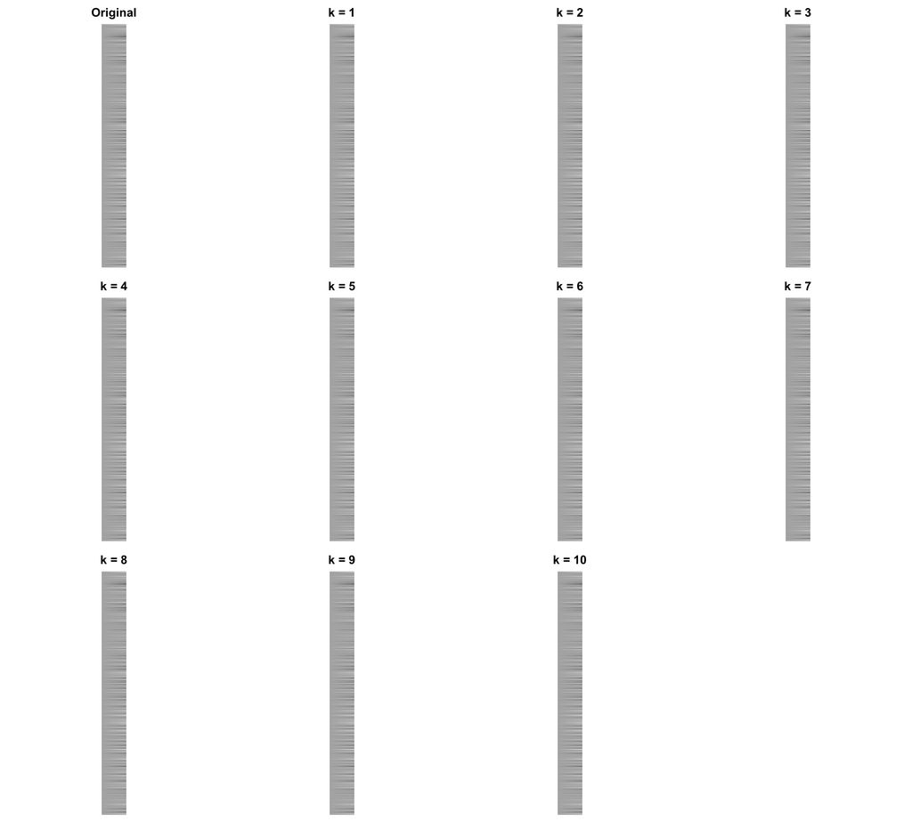

```r
par(mfrow = c(3, 4), mar = c(0.5, 0.5, 2, 0.5))
plot_img(x2, "Original", rng = rng2)
for (k in 1:10) plot_img(approx_k(P2, k), paste("k =", k), rng = rng2)
par(mfrow = c(1, 1), mar = c(5, 4, 4, 2) + 0.1)
```

All eleven panels are indistinguishable, because the rank 1 approximation already reproduces the image. Its Frobenius error is 2.05 against a total magnitude of 37,539, or about 0.005%.

### Approximation error vs. k

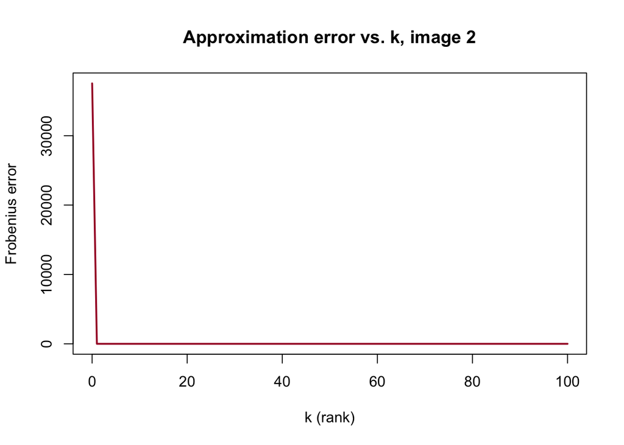

```r
plot(0:p2, c(norm(x2, type = "F"), P2$error), type = "l", lwd = 2,
     col = "#A71930",
     xlab = "k (rank)", ylab = "Frobenius error",
     main = "Approximation error vs. k, image 2")
```

### First eigenvector and first PC score

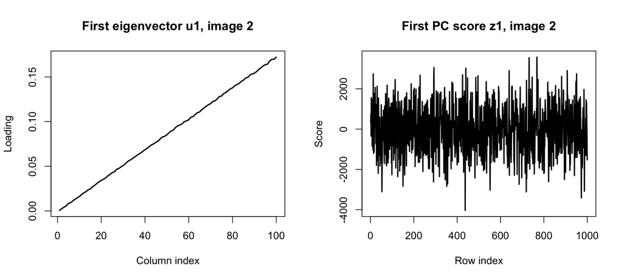

```r
par(mfrow = c(1, 2))
plot(P2$U[, 1], type = "l", lwd = 2, xlab = "Column index", ylab = "Loading",
     main = "First eigenvector u1, image 2")
plot(P2$Z[, 1], type = "l", lwd = 2, xlab = "Row index", ylab = "Score",
     main = "First PC score z1, image 2")
```

```r
par(mfrow = c(1, 1))
```

The first eigenvector rises steadily from 0 at column 1 to about 0.17 at column 100, so the single pattern underlying this image is a left-to-right brightness gradient. The first PC score varies between roughly −4,000 and +3,500 with no trend down the image, and it gives each row’s multiple of that gradient. Rows with large positive scores show the gradient as it is, rows with large negative scores show it reversed (bright on the left, dark on the right), and rows near zero are nearly uniform. This is what produces the horizontal banding in the original.

Plotting a few rows directly makes the structure obvious:

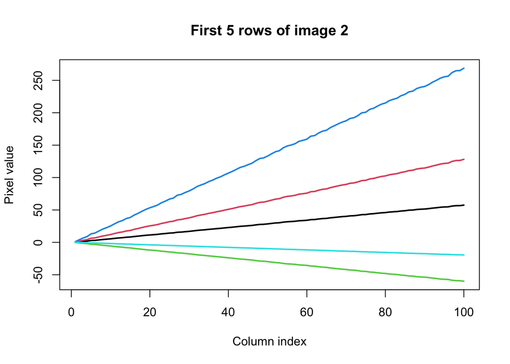

```r
matplot(t(x2[1:5, ]), type = "l", lwd = 2, lty = 1,
        xlab = "Column index", ylab = "Pixel value",
        main = "First 5 rows of image 2")
```

Each row is a straight line through the origin with its own slope. They differ only by a scale factor, which is precisely what it means for the matrix to be rank 1.

**My choice: k = 1.** The rank 1 approximation is visually identical to the original and has a relative error of about 0.005%. It stores 1,100 numbers instead of 100,000, roughly 1% of the original. This is the best case for PCA compression, because the image genuinely contains only one pattern. It stands in contrast to image 1, where k = 1 is also the right answer but for the opposite reason: there, everything beyond the first component is noise worth discarding, while here there is simply nothing beyond the first component at all.

## Image 3

```r
x3 <- data.matrix(read_csv("data/image3.csv"))
P3 <- pca_parts(x3)
n3 <- nrow(x3); p3 <- ncol(x3); rng3 <- range(x3)
dim(x3)
```

```
## [1] 376 345
```

```r
round(P3$lambda[1:10])
```

```
##  [1] 80137 18598  8482  5449  2821  2281  2033  1572  1191   893
```

Image 3 is a photograph of a puppy, and its eigenvalues behave like a real image: they decline smoothly from 80,137 rather than collapsing to zero. The pixel values have been standardized to mean 0 and standard deviation 1, so dark pixels are negative and light pixels are positive.

### Original and rank 1–10 approximations

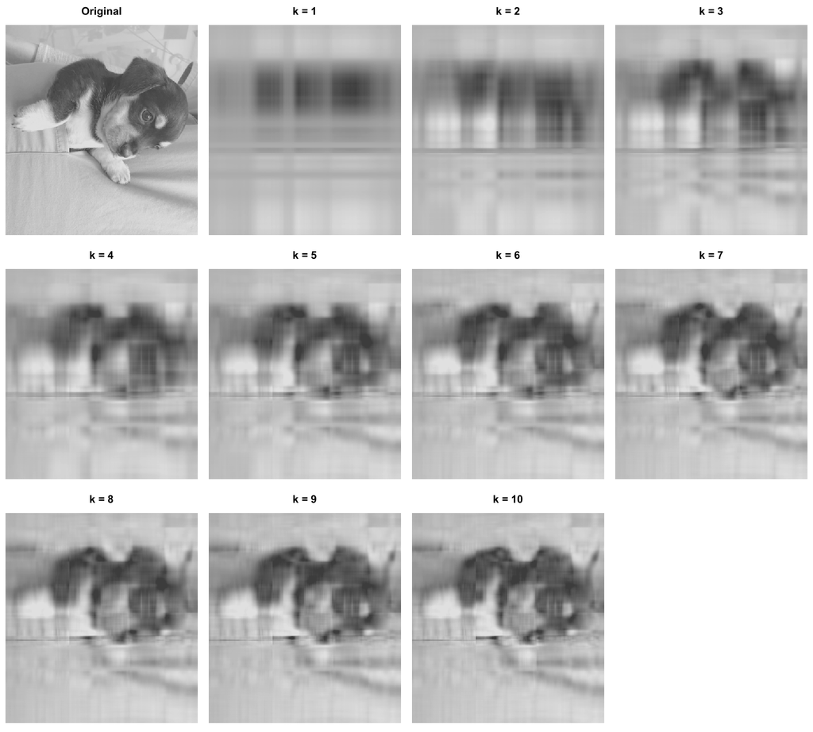

```r
par(mfrow = c(3, 4), mar = c(0.5, 0.5, 2, 0.5))
plot_img(x3, "Original", rng = rng3)
for (k in 1:10) plot_img(approx_k(P3, k), paste("k =", k), rng = rng3)
par(mfrow = c(1, 1), mar = c(5, 4, 4, 2) + 0.1)
```

Here the approximations visibly improve. At k = 1 there is only a dark band across the middle. The white chest and paw appear by k = 3, the shape is clearly a dog by k = 5, and the face, ear and snout are defined by k = 10. The blocky vertical streaking at low k is characteristic of PCA on images, since each component is a pattern spanning the full width of the frame.

### Approximation error vs. k

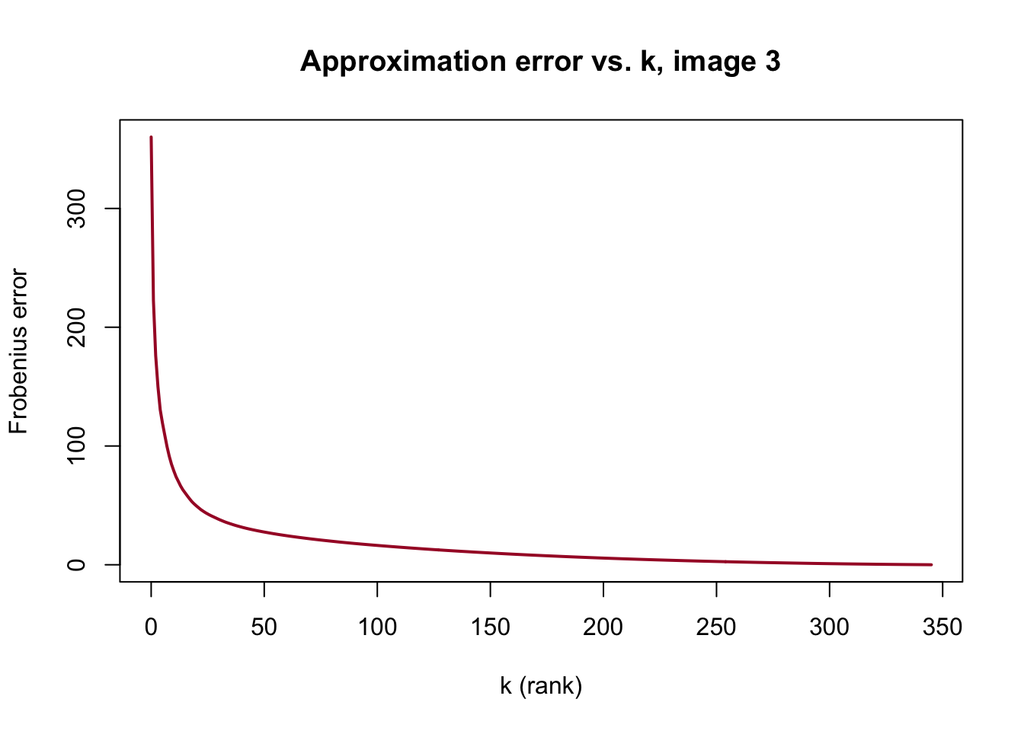

```r
plot(0:p3, c(norm(x3, type = "F"), P3$error), type = "l", lwd = 2,
     col = "#A71930",
     xlab = "k (rank)", ylab = "Frobenius error",
     main = "Approximation error vs. k, image 3")
```

This is the classic shape for a compressible image: a steep drop over the first ten or so components, then a long flat tail. It contrasts with image 1, where the decline was nearly linear, and with image 2, where the curve fell to zero at k = 1 and stayed there.

### First eigenvector and first PC score

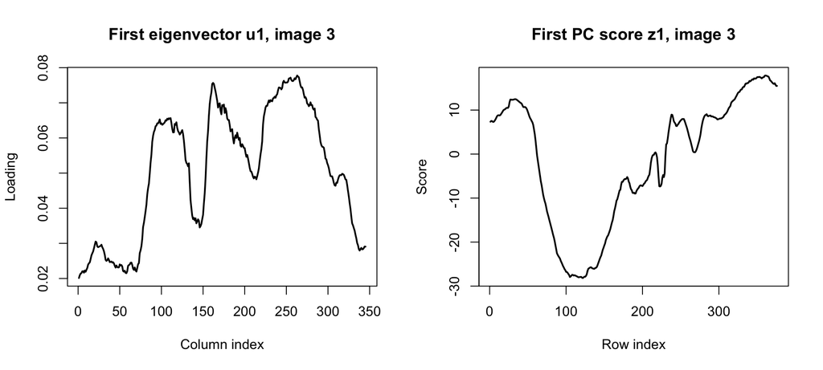

```r
par(mfrow = c(1, 2))
plot(P3$U[, 1], type = "l", lwd = 2, xlab = "Column index", ylab = "Loading",
     main = "First eigenvector u1, image 3")
plot(P3$Z[, 1], type = "l", lwd = 2, xlab = "Row index", ylab = "Score",
     main = "First PC score z1, image 3")
```

```r
par(mfrow = c(1, 1))
```

The first eigenvector is positive for all 345 columns but varies in size. It is small (around 0.02) for columns 1 to 90, which contain mostly flat background, and much larger (0.05 to 0.08) for columns 90 to 300, which contain the puppy. The first component therefore emphasizes the part of the frame where the strongest light–dark contrast occurs. The first PC score gives each row’s weight on that pattern: it is positive near the top and bottom, where the rows are mostly light blanket, and drops to about −28 around rows 100 to 150, where the rows pass through the puppy’s dark head and body. Because the values are standardized, a negative score means the row is darker than average. The rank 1 approximation is therefore a coarse map of where the dark subject sits against the light background, which is exactly the blurred band seen in the k = 1 panel.

### Choosing k

```r
rel3 <- P3$error / norm(x3, type = "F")
for (k in c(10, 20, 30, 40, 50, 90)) {
  cat("k =", k, " rel error =", round(rel3[k], 3),
      " storage =", round(100 * k * (n3 + p3) / (n3 * p3), 1), "%\n")
}
```

```
## k = 10  rel error = 0.22  storage = 5.6 %
## k = 20  rel error = 0.138  storage = 11.1 %
## k = 30  rel error = 0.106  storage = 16.7 %
## k = 40  rel error = 0.088  storage = 22.2 %
## k = 50  rel error = 0.077  storage = 27.8 %
## k = 90  rel error = 0.05  storage = 50 %
```

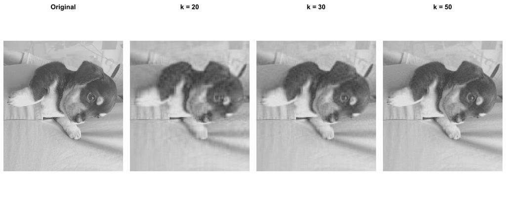

```r
par(mfrow = c(1, 4), mar = c(0.5, 0.5, 2, 0.5))
plot_img(x3, "Original", rng = rng3)
for (k in c(20, 30, 50)) plot_img(approx_k(P3, k), paste("k =", k), rng = rng3)
```

```r
par(mfrow = c(1, 1), mar = c(5, 4, 4, 2) + 0.1)
```

**My choice: k = 30.** The image is recognizable by k = 6 and detailed by k = 20, and at k = 30 it is hard to distinguish from the original at normal viewing size while using only 16.7% of the original storage. The Frobenius criterion is much stricter: reaching 5% relative error takes k = 90, which costs 50% of the original storage and halves the benefit of compressing at all. That remaining error sits in fine blanket texture and image noise, which contribute to the squared error but are not visually important, so I chose the smaller k based on appearance rather than on the error metric alone.

## Image 4

```r
x4 <- data.matrix(read_csv("data/image4.csv"))
P4 <- pca_parts(x4)
n4 <- nrow(x4); p4 <- ncol(x4); rng4 <- range(x4)
dim(x4)
```

```
## [1] 213 119
```

Image 4 is a 213 × 119 photograph of a blurry outdoor scene containing a few bright objects. Like image 3, its values are standardized. It is much smaller than the other images, which turns out to matter for how well PCA compresses it.

### Original and rank 1–10 approximations

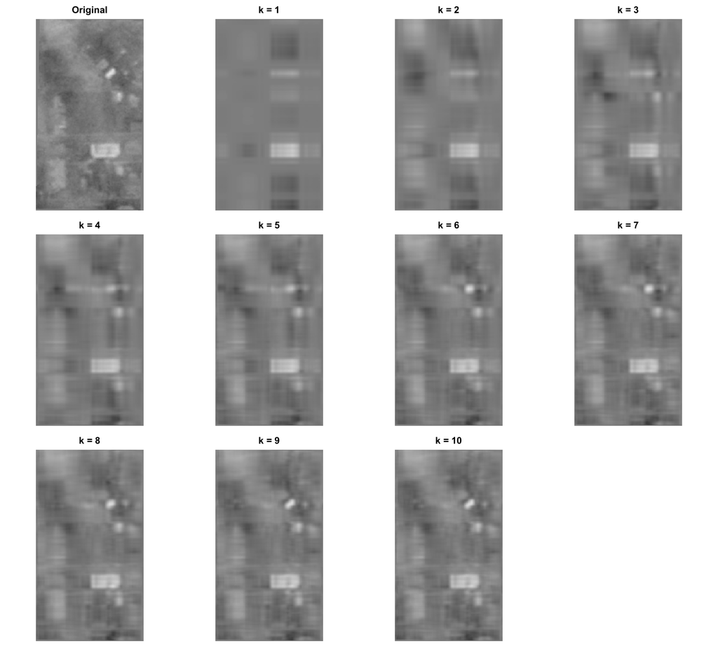

```r
par(mfrow = c(3, 4), mar = c(0.5, 0.5, 2, 0.5))
plot_img(x4, "Original", rng = rng4)
for (k in 1:10) plot_img(approx_k(P4, k), paste("k =", k), rng = rng4)
par(mfrow = c(1, 1), mar = c(5, 4, 4, 2) + 0.1)
```

### Approximation error vs. k

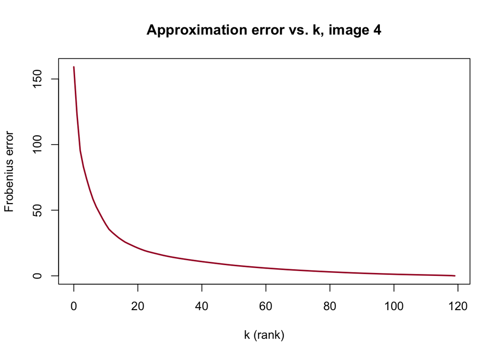

```r
plot(0:p4, c(norm(x4, type = "F"), P4$error), type = "l", lwd = 2,
     col = "#A71930",
     xlab = "k (rank)", ylab = "Frobenius error",
     main = "Approximation error vs. k, image 4")
```

### First eigenvector and first PC score

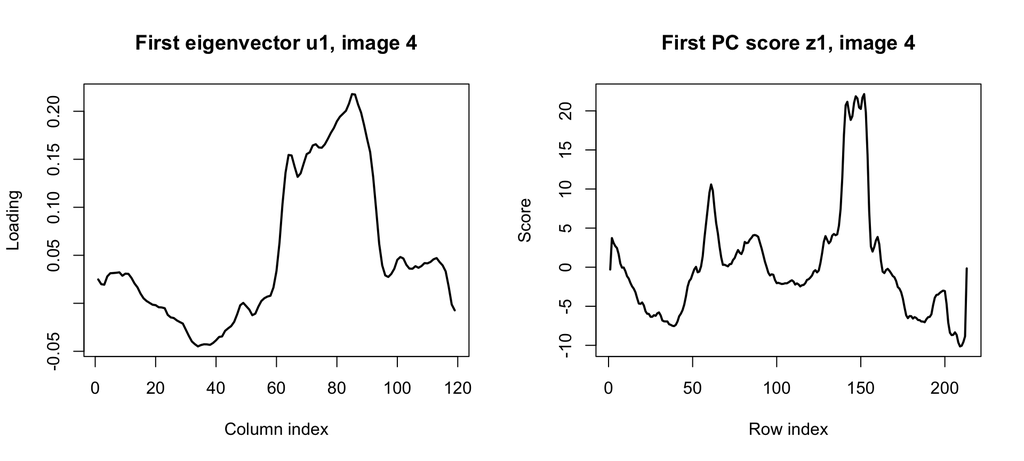

```r
par(mfrow = c(1, 2))
plot(P4$U[, 1], type = "l", lwd = 2, xlab = "Column index", ylab = "Loading",
     main = "First eigenvector u1, image 4")
plot(P4$Z[, 1], type = "l", lwd = 2, xlab = "Row index", ylab = "Score",
     main = "First PC score z1, image 4")
```

```r
par(mfrow = c(1, 1))
```

The first eigenvector peaks sharply at about 0.22 near column 85 and dips slightly negative near columns 30 to 45. Unlike the earlier images, where the first eigenvector was positive throughout, this pattern contrasts two regions: brightness concentrated around column 85 against a relatively darker region near column 35. The first PC score peaks at about 10 near row 60 and about 22 near row 150, which are the rows containing the bright objects, and is negative around rows 30 to 50 and near the bottom of the image. The first component is therefore acting as a detector for the brightest features in the frame rather than describing the scene as a whole, which is why the k = 1 approximation shows little more than bright patches against a flat background.

### Choosing k

```r
rel4 <- P4$error / norm(x4, type = "F")
for (k in c(10, 20, 30, 40, 50)) {
  cat("k =", k, " rel error =", round(rel4[k], 3),
      " storage =", round(100 * k * (n4 + p4) / (n4 * p4), 1), "%\n")
}
```

```
## k = 10  rel error = 0.246  storage = 13.1 %
## k = 20  rel error = 0.133  storage = 26.2 %
## k = 30  rel error = 0.091  storage = 39.3 %
## k = 40  rel error = 0.068  storage = 52.4 %
## k = 50  rel error = 0.05  storage = 65.5 %
```

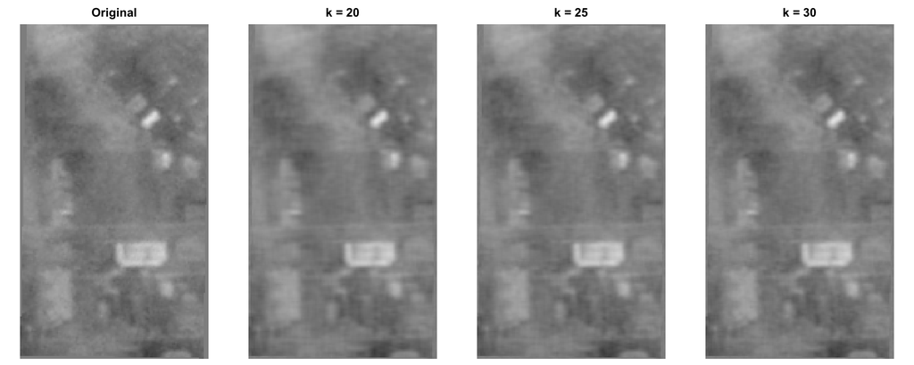

```r
par(mfrow = c(1, 4), mar = c(0.5, 0.5, 2, 0.5))
plot_img(x4, "Original", rng = rng4)
for (k in c(20, 25, 30)) plot_img(approx_k(P4, k), paste("k =", k), rng = rng4)
```

```r
par(mfrow = c(1, 1), mar = c(5, 4, 4, 2) + 0.1)
```

**My choice: k = 20.** The scene reads as coherent by about k = 20, and since the original is already blurry there is little fine detail to recover beyond that. The more important consideration here is that compression works poorly on an image this small. Storage cost is k(n + p) / np, and with n + p = 332 against np = 25,347 each component costs about 1.3% of the original. At k = 20 the approximation already uses 26% of the original storage, and k = 40 uses 52%. Image 3, which is larger and squarer, reached a similar visual quality at 16.7%. I would accept 13% relative error at k = 20 rather than spend half the original file size for a difference that is barely visible.

## Summary

| Image | Size | Chosen k | Relative error | Storage |
| --- | --- | --- | --- | --- |
| 1 | 1000 × 100 | 1 | 44.5% | 1.1% |
| 2 | 1000 × 100 | 1 | 0.005% | 1.1% |
| 3 | 376 × 345 | 30 | 10.6% | 16.7% |
| 4 | 213 × 119 | 20 | 13.3% | 26.2% |

How well PCA compresses an image depends entirely on whether the image has structure that a small number of patterns can describe. Image 2 is genuinely rank 1 and compresses perfectly. Image 1 has one real feature and 99 dimensions of noise, so k = 1 captures everything meaningful and no larger k improves the picture, even though its relative error stays at 44.5%. Images 3 and 4 are real photographs that need tens of components, and image 4 shows that a small image compresses poorly regardless of its content, because each component costs proportionally more to store.